# Lab13_Aditya_Mhaske

[Run in Google Colab](https://colab.research.google.com/github/yy/dviz-course/blob/master/docs/m13-text/lab13.ipynb)

[figure not shown]

View on Github

[figure not shown]

View raw on Github

# Module 13: Texts

We'll use `spaCy` and `wordcloud` to play with text data. `spaCy` is probably the best python package for analyzing text data. It's capable and super fast. Let's install them.

```
pip install wordcloud spacy
```

To use spaCy, you also need to download models. Run:

```
python -m spacy download en_core_web_sm
```

## SpaCy basics

```python
pip install wordcloud spacy
```

```python
!python -m spacy download en_core_web_sm
```

[output not shown]

```python
import spacy
import wordcloud

nlp = spacy.load('en_core_web_sm')
```

Usually the first step of text analysis is *tokenization*, which is the process of breaking a document into "tokens". You can roughly think of it as extracting each word.

```python
doc = nlp(u'Apple is looking at buying U.K. startup for $1 billion')

for token in doc:
    print(token)
```

```
Apple
is
looking
at
buying
U.K.
startup
for
$
1
billion
```

As you can see, it's not exactly same as `doc.split()`. You'd want to have `$` as a separate token because it has a particular meaning (USD). Actually, as shown in an example (https://spacy.io/usage/spacy-101#annotations-pos-deps), `spaCy` figures out a lot of things about these tokens. For instance,

```python
for token in doc:
    print(token.text, token.lemma_, token.pos_, token.tag_)
```

```
Apple Apple PROPN NNP
is be AUX VBZ
looking look VERB VBG
at at ADP IN
buying buy VERB VBG
U.K. U.K. PROPN NNP
startup startup NOUN NN
for for ADP IN
$ $ SYM $
1 1 NUM CD
billion billion NUM CD
```

It figured it out that `Apple` is a proper noun ("PROPN" and "NNP"; see [here](https://www.ling.upenn.edu/courses/Fall_2003/ling001/penn_treebank_pos.html) for the part of speech tags).

`spaCy` has a visualizer too.

```python
from spacy import displacy
displacy.render(doc, style='dep', jupyter=True, options={'distance': 100})
```

[figure not shown]

It even recognizes entities and can visualize them.

```python
text = """But Google is starting from behind. The company made a late push
into hardware, and Apple’s Siri, available on iPhones, and Amazon’s Alexa
software, which runs on its Echo and Dot devices, have clear leads in
consumer adoption."""

doc2 = nlp(text)
displacy.render(doc2, style='ent', jupyter=True)
```

But Google ORG is starting from behind. The company made a late push  
into hardware, and Apple ORG ’s Siri PERSON , available on iPhones ORG , and Amazon ORG ’s Alexa ORG  
software, which runs on its Echo LOC and Dot devices, have clear leads in  
consumer adoption.

## Let's read a book

Shall we load some serious book? You can use any books that you can find as a text file.

```python
import urllib.request

book = urllib.request.urlopen('https://sherlock-holm.es/stories/plain-text/stud.txt').read()
```

```python
book[:1000]
```

```
b'\n\n\n\n                               A STUDY IN SCARLET\n\n                               Arthur Conan Doyle\n\n\n\n\n\n\n\n                                Table of contents\n\n         Part I\n        Mr. Sherlock Holmes\n        The Science Of Deduction\n        The Lauriston Garden Mystery\n …
```

Looks like we have successfully loaded the book. You'd probably want to remove the parts at the beginning and at the end that are not parts of the book if you are doing a serious analysis, but let's ignore them for now. Let's try to feed this directly into `spaCy`.

```python
doc = nlp(book)
```

[output not shown]

## On encodings

```python
type(book)
```

```
bytes
```

Well, the problem is that a byte sequence is not yet a proper string until we know how to decode it. A string is an abstract object and we need to specify an encoding to write the string into a file. For instance, if I have a string of Korean characters like "안녕", there are several encodings that I can specify to write that into a file, and depending on the encoding that I choose, the byte sequences can be totally different from each other. This is a really important (and confusing) topic, but because it's beyond the scope of the course, I'll just link a nice post about encoding: http://kunststube.net/encoding/

```python
"안녕".encode('utf8')
```

```
b'\xec\x95\x88\xeb\x85\x95'
```

```python
# b'\xec\x95\x88\xeb\x85\x95'.decode('euc-kr') <- what happen if you do this?
b'\xec\x95\x88\xeb\x85\x95'.decode('utf8')
```

```
'안녕'
```

```python
"안녕".encode('euc-kr')
```

```
b'\xbe\xc8\xb3\xe7'
```

```python
b'\xbe\xc8\xb3\xe7'.decode('euc-kr')
```

```
'안녕'
```

You can decode with "wrong" encoding too.

```python
b'\xbe\xc8\xb3\xe7'.decode('latin-1')
```

```
'¾È³ç'
```

As you can see the same string can be encoded into different byte sequences depending on the encoding. It's a really annoying fun topic and if you need to deal with text data, you must have a good understanding of it.

There is a lot of complexity in encoding. But for now, just remember that `utf-8` encoding is the most common encoding. It is also compatible with ASCII encoding as well. That means you can *decode* both ASCII and utf-8 documents with utf-8 encoding. So let's decode the byte sequence into a string.

```python
# YOUR SOLUTION HERE
book_str = book.decode('utf-8')
```

```python
type(book_str)
```

```
str
```

Shall we try again?

```python
doc = nlp(book_str)
```

```python
words = [token.text for token in doc
         if token.is_stop != True and token.is_punct != True]
```

## Let's count!

```python
from collections import Counter

Counter(words).most_common(5)
```

```
[('\n     ', 3107),
 ('\n\n     ', 772),
 ('said', 207),
 ('man', 155),
 ('Holmes', 98)]
```

a lot of newline characters and multiple spaces. A quick and dirty way to remove them is split & join. The idea is that you split the document using `split()` and then join with a single space . Can you implement it and print the 10 most common words?

```python
# YOUR SOLUTION HERE

words_split = [word for word in words if word != '\n' and word != '\n\n']
words_joined = ' '.join(words_split)
words = words_joined.split()
counter = Counter(words)
most_common_words = counter.most_common(10)
most_common_words
```

```
[('said', 207),
 ('man', 155),
 ('Holmes', 98),
 ('little', 80),
 ('time', 77),
 ('way', 69),
 ('came', 67),
 ('face', 67),
 ('asked', 65),
 ('come', 64)]
```

Let's keep the object with word count.

```python
word_cnt = Counter(words)
```

## Some wordclouds?

```python
import matplotlib.pyplot as plt
%matplotlib inline
```

Can you check out the `wordcloud` package documentation and create a word cloud from the word count object that we created from the book above and plot it?

```python
# Implement: create a word cloud object

# YOUR SOLUTION HERE
from wordcloud import WordCloud
wordcloud = WordCloud(width=900, height=500, max_words = 500, background_color='black').generate_from_frequencies(word_cnt)
```

```
(-0.5, 899.5, 499.5, -0.5)
```

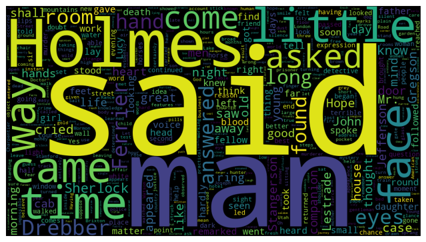

```python
# Implement: plot the word cloud object

# YOUR SOLUTION HERE
plt.figure(figsize=(10, 5))
plt.imshow(wordcloud)
plt.axis('off')
```

**Q: Can you create a word cloud for a certain part of speech, such as nouns, verbs, proper nouns, etc. (pick one)?**

```
(-0.5, 899.5, 499.5, -0.5)
```

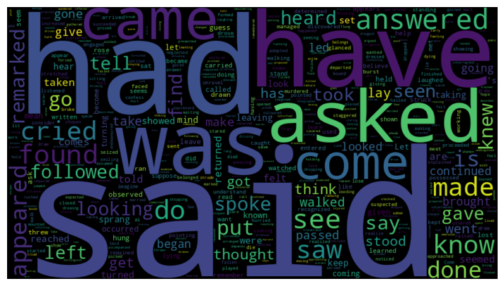

```python
# YOUR SOLUTION HERE

nouns = [token.text for token in doc if token.pos_ == 'VERB']
noun_counter = Counter(nouns)
noun_wordcloud = WordCloud(width=900, height=500, max_words=500, background_color='black').generate_from_frequencies(noun_counter)
plt.figure(figsize=(10, 5))
plt.imshow(noun_wordcloud, interpolation='bilinear')
plt.axis('off')
```